# Team

Kellan Bouwman & Felix Baez-Santiago

10/11/2020

## Part one: Cleaning data

Although the three Excel sheets are loaded into R, they are not useful before some cleaning. Manipulate the three imported data frames, so that in the cleaned dataset:

0. Load Files

```r
# dplyr
library(dplyr)
```

```r
# ggplot2
library(ggplot2)
#Libary
library(tidyr)
#Libary
library(readxl)
defense <- read_excel('cyclonesFootball2019.xlsx', sheet='Defensive')
offensive <- read_excel('cyclonesFootball2019.xlsx', sheet='Offensive')
Biography <- read_excel('cyclonesFootball2019.xlsx', sheet='Biography')
```

1. The player names and opponent names are factors.

   ```
    In both of these blocks I will both turn names and opponent names to factors and also change the columns to numeric
   ```

```r
defClean <- defense %>%
              mutate(across(c("Name", "Opponent_Opponent"), as.factor)) %>% #changing Name and Opponent_Opponent in offClean to factors
              mutate_if(is.character, as.numeric, na.rm = TRUE) #turning values to numeric
str(defClean)
```

```
## tibble [502 × 11] (S3: tbl_df/tbl/data.frame)
##  $ Name             : Factor w/ 43 levels "Akers, Landen",..: 40 40 40 40 40 40 40 40 40 40 ...
##  $ Opponent_Opponent: Factor w/ 13 levels "Baylor","Iowa",..: 12 2 11 1 8 13 10 7 6 9 ...
##  $ Tackles_Solo     : num [1:502] 4 4 3 4 3 1 7 3 6 5 ...
##  $ Tackles_ASST     : num [1:502] 4 7 5 2 2 1 1 2 1 5 ...
##  $ Tackles_TFL      : num [1:502] 0 0 0 0 1 0 0 0 1 1 ...
##  $ Tackles_Sack     : num [1:502] 0 0 0 0 0 0 0 0 0 1 ...
##  $ Turnover_FF      : num [1:502] 0 0 0 0 0 0 0 0 0 0 ...
##  $ Turnover_FR      : num [1:502] 0 0 0 0 0 0 0 0 0 0 ...
##  $ Turnover_INT     : num [1:502] 0 0 1 0 0 0 0 0 1 0 ...
##  $ Pass_QBH         : num [1:502] 1 0 0 0 0 0 0 0 1 0 ...
##  $ Pass_PB          : num [1:502] 1 2 0 0 0 1 0 0 0 0 ...
```

```r
offClean <- offensive %>%
              mutate(across(c("Name", "Opponent_Opponent"), as.factor)) %>% #changing Name and Opponent_Opponent in defClean to factors
              mutate_if(is.character, as.numeric, na.rm = TRUE) #turning values to numeric
offClean <- offClean %>%
                replace(is.na(.), 0) #replacing NAs with 0s
str(offClean)
```

```
## tibble [195 × 12] (S3: tbl_df/tbl/data.frame)
##  $ Name             : Factor w/ 17 levels "Akers, Landen",..: 1 1 1 1 1 1 1 1 1 1 ...
##  $ Opponent_Opponent: Factor w/ 13 levels "Baylor","Iowa",..: 12 2 11 1 8 13 10 7 6 9 ...
##  $ Rushing_ATT      : num [1:195] 0 0 1 0 0 0 0 0 0 0 ...
##  $ Rushing_YDS      : num [1:195] 0 0 8 0 0 0 0 0 0 0 ...
##  $ Rushing_TD       : num [1:195] 0 0 0 0 0 0 0 0 0 0 ...
##  $ Receiving_REC    : num [1:195] 1 0 0 0 1 0 0 4 0 1 ...
##  $ Receiving_YDS    : num [1:195] 21 0 0 0 32 0 0 39 0 7 ...
##  $ Receiving_TD     : num [1:195] 0 0 0 0 0 0 0 0 0 0 ...
##  $ Passing_CMP-ATT  : num [1:195] 0 0 0 0 0 0 0 0 0 0 ...
##  $ Passing_YDS      : num [1:195] 0 0 0 0 0 0 0 0 0 0 ...
##  $ Passing_TD       : num [1:195] 0 0 0 0 0 0 0 0 0 0 ...
##  $ Passing_INT      : num [1:195] 0 0 0 0 0 0 0 0 0 0 ...
```

2. All offensive and defensive statistics are numerical. The Weight column in biogrpahy is also numeric. (Optional: Learn to mutate multiple columns systematically using the ?across function in `dplyr)

   This was done in defClean and offClean

```r
#Already done in question 1
```

3. Change the Height column in biogrpahy into numeric. (Hint: Use a unit that works well)

   Printed answer.

```r
bioClean <- Biography %>%
              mutate(Name = as.factor(Name)) %>%
              mutate(Height = gsub("-", ".", Height)) %>% #remove the - from height and convert to feet
              mutate(across(c("Height", "Weight"), as.numeric)) #turning height and weight into a numeric column
str(bioClean)
```

```
## tibble [105 × 7] (S3: tbl_df/tbl/data.frame)
##  $ Name      : Factor w/ 105 levels "Akers, Landen",..: 1 2 3 4 5 6 7 8 9 10 ...
##  $ Position  : chr [1:105] "Wide Receiver" "Tight End" "Wide Receiver" "Placekicker" ...
##  $ Height    : num [1:105] 6 6.7 6.5 6 6 6.3 6.2 6.2 6 6.6 ...
##  $ Weight    : num [1:105] 188 245 204 195 190 235 255 285 300 215 ...
##  $ Class     : chr [1:105] "Redshirt Senior" "Redshirt Senior" "Redshirt Freshman" "Redshirt Senior" ...
##  $ Hometown  : chr [1:105] "Cedar Rapids, Iowa" "Nixa, Mo." "Seffner, Fla." "Naperville, Ill." ...
##  $ Highschool: chr [1:105] "Washington" "Nixa" "Armwood" "Central" ...
```

By cleaning the three data frames in R, at the end of this step you should have the following three clean data frames: defClean, offClean, and bioClean. Print the structures of these data frames.

## Part two: Tidying

For the following questions, work on the cleaned data frames defClean, offClean, and bioClean.

1. Reformat the defClean data frame into a tidy format using pivot_longer. The type of statistic (Tackles_Solo, Tackles_ASST, etc) is added as a new key column named stat.

   Cleaned data pivoted

```r
defCleanOrig <- defClean
defClean %>%
  pivot_longer(Tackles_Solo:Pass_PB, names_to = "stat", values_to = "Score") -> defClean

str(defClean)
```

```
## tibble [4,518 × 4] (S3: tbl_df/tbl/data.frame)
##  $ Name             : Factor w/ 43 levels "Akers, Landen",..: 40 40 40 40 40 40 40 40 40 40 ...
##  $ Opponent_Opponent: Factor w/ 13 levels "Baylor","Iowa",..: 12 12 12 12 12 12 12 12 12 2 ...
##  $ stat             : chr [1:4518] "Tackles_Solo" "Tackles_ASST" "Tackles_TFL" "Tackles_Sack" ...
##  $ Score            : num [1:4518] 4 4 0 0 0 0 0 1 1 4 ...
```

```r
print(defClean)
```

```
## # A tibble: 4,518 x 4
##    Name            Opponent_Opponent stat         Score
##    <fct>           <fct>             <chr>        <dbl>
##  1 White, Lawrence UNI               Tackles_Solo     4
##  2 White, Lawrence UNI               Tackles_ASST     4
##  3 White, Lawrence UNI               Tackles_TFL      0
##  4 White, Lawrence UNI               Tackles_Sack     0
##  5 White, Lawrence UNI               Turnover_FF      0
##  6 White, Lawrence UNI               Turnover_FR      0
##  7 White, Lawrence UNI               Turnover_INT     0
##  8 White, Lawrence UNI               Pass_QBH         1
##  9 White, Lawrence UNI               Pass_PB          1
## 10 White, Lawrence Iowa              Tackles_Solo     4
## # … with 4,508 more rows
```

2. Compare the distributions of the defensive statistics. What defensive skills are rare?

   Turnover_FF, Turnover_FR, and Turnover_Int are all about the same in terms of rarity, with the 0 count reaching 500. Tackles_Sack is the next rarest with 0 reaching almost 500. The Turnover skills are the rarest with a largest count of 0.

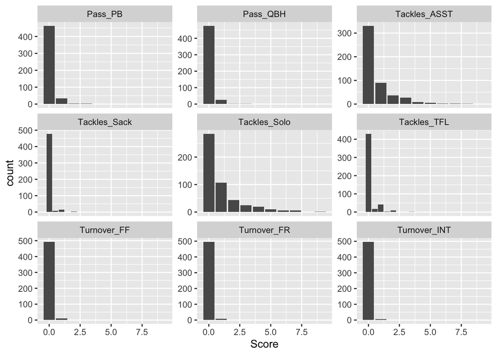

```r
ggplot(defClean, aes(x = Score)) +  geom_bar() + facet_wrap(~stat, scales = 'free_y')
```

3. Did ISU have better defense against Iowa or Notre Dame? Answer this question by creating a scatterplot with x- and y-axes being the number of solo tackles (of each player). A large number of solo tackles is an indicator of good defense.

   ISU had better defense in the UNI game. The tackles reach over 6 per player where as in the Notre Dame game they only cross the 5 per player thresh hold.

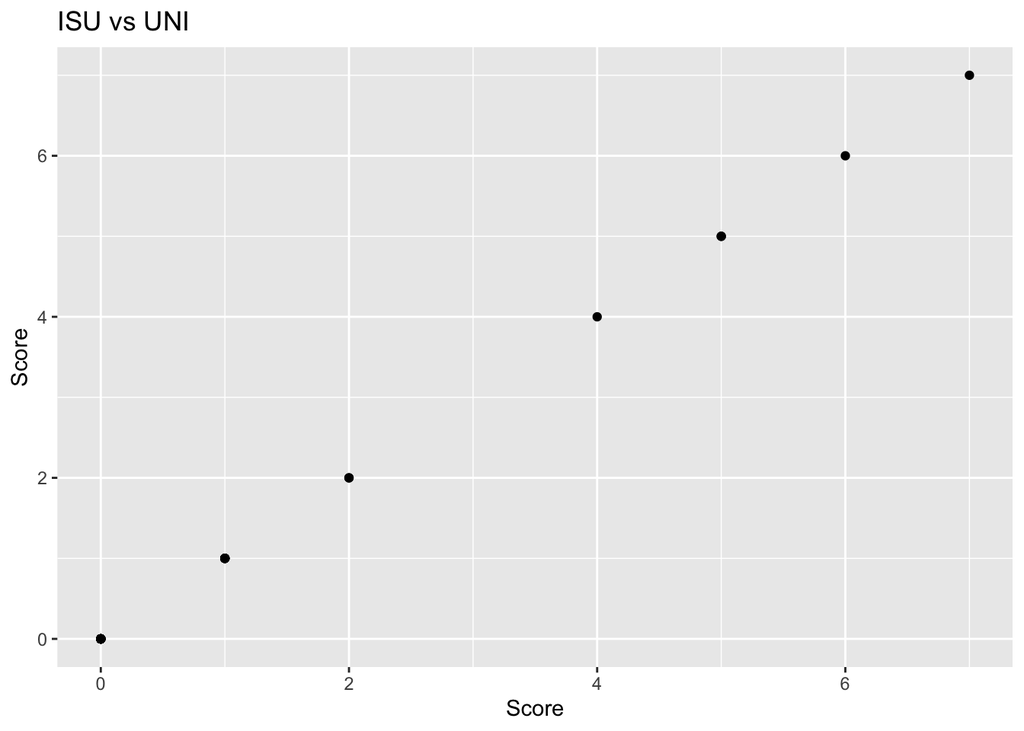

```r
defClean %>%
  filter(stat == "Tackles_Solo" & Opponent_Opponent == "UNI") -> SoloUNI
defClean %>%
  filter(stat == "Tackles_Solo" & Opponent_Opponent == "Notre Dame") -> SoloND

ggplot(SoloUNI, aes(x=Score, y=Score)) + geom_point() + labs(title="ISU vs UNI")
```

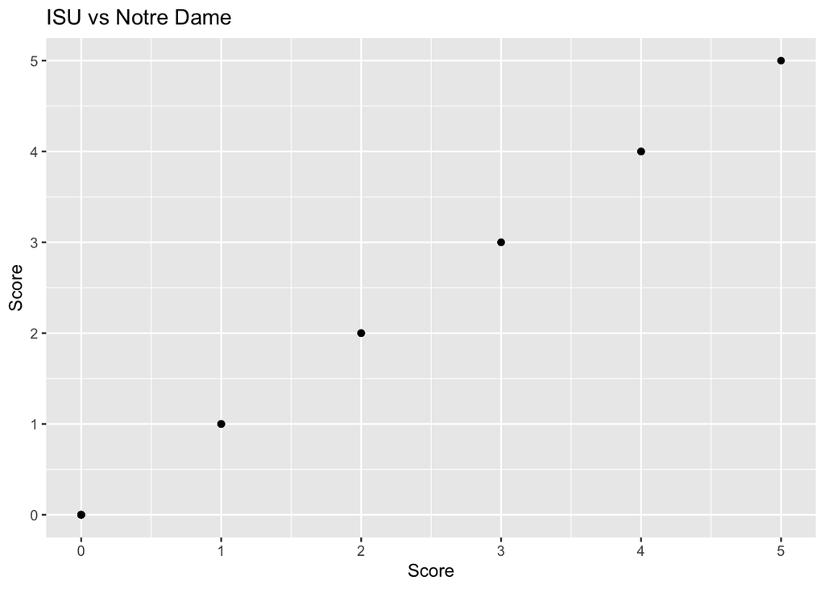

```r
ggplot(SoloND, aes(x=Score, y=Score)) + geom_point()  + labs(title="ISU vs Notre Dame")
```

Now turn our attention to the player biography.

4. Separate the Hometown column into two columns, namely the city and the state. Print the first few rows of these two columns. (Hint: look at the sep= argument of separate)

   Answer

```r
bioClean <- bioClean %>%
  separate(Hometown, into = c("City", "state"), sep = ",") #separate hometown into city state and separate by commas
head(bioClean) #print
```

```
## # A tibble: 6 x 8
##   Name         Position    Height Weight Class       City      state  Highschool
##   <fct>        <chr>        <dbl>  <dbl> <chr>       <chr>     <chr>  <chr>
## 1 Akers, Land… Wide Recei…    6      188 Redshirt S… Cedar Ra… " Iow… Washington
## 2 Allen, Chase Tight End      6.7    245 Redshirt S… Nixa      " Mo." Nixa
## 3 Anderson, E… Wide Recei…    6.5    204 Redshirt F… Seffner   " Fla… Armwood
## 4 Assalley, C… Placekicker    6      195 Redshirt S… Napervil… " Ill… Central
## 5 Azunna, Arn… Defensive …    6      190 Redshirt S… Grand Pr… " Tex… Lake Ridge
## 6 Bailey, Cor… Defensive …    6.3    235 Redshirt J… Clarksda… " Mis… Clarksdale
```

5. How many players are there from each state?

   Most of ISU players are from Iowa.

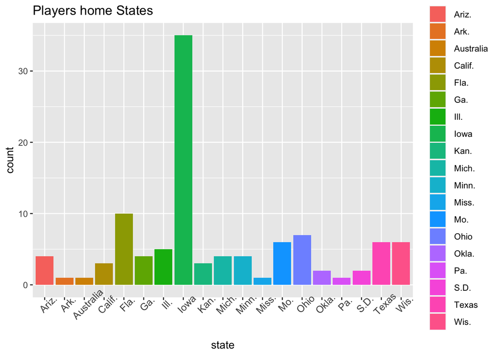

```r
ggplot(bioClean, aes(x = state, fill = state)) +  geom_bar() + labs(title = "Players home States") + theme(axis.text.x = element_text(size=10, angle=45))
```

```r
bioClean %>%
  group_by(state) %>%
  summarize(count = n())
```

```
## # A tibble: 19 x 2
##    state        count
##    <chr>        <int>
##  1 " Ariz."         4
##  2 " Ark."          1
##  3 " Australia"     1
##  4 " Calif."        3
##  5 " Fla."         10
##  6 " Ga."           4
##  7 " Ill."          5
##  8 " Iowa"         35
##  9 " Kan."          3
## 10 " Mich."         4
## 11 " Minn."         4
## 12 " Miss."         1
## 13 " Mo."           6
## 14 " Ohio"          7
## 15 " Okla."         2
## 16 " Pa."           1
## 17 " S.D."          2
## 18 " Texas"         6
## 19 " Wis."          6
```

## Part three: Joining data frames

1. Find which states do the ISU defensive and offensive players come from. Create an appropriate summary.

   Printed answer.

```r
bioClean %>%
  inner_join(defClean) -> defBio
```

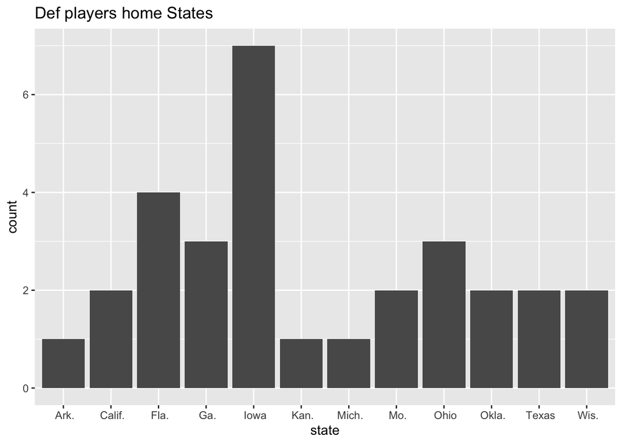

```r
defBio <- defBio %>%
  select(state, Name) %>%
  distinct(Name, .keep_all = TRUE)

ggplot(defBio, aes(x = state)) +  geom_bar() + labs(title = "Def players home States")
```

```r
defBio %>%
  group_by(state) %>%
  summarize(count = n())
```

```
## # A tibble: 12 x 2
##    state     count
##    <chr>     <int>
##  1 " Ark."       1
##  2 " Calif."     2
##  3 " Fla."       4
##  4 " Ga."        3
##  5 " Iowa"       7
##  6 " Kan."       1
##  7 " Mich."      1
##  8 " Mo."        2
##  9 " Ohio"       3
## 10 " Okla."      2
## 11 " Texas"      2
## 12 " Wis."       2
```

```r
bioClean %>%
  inner_join(offClean) -> offBio
```

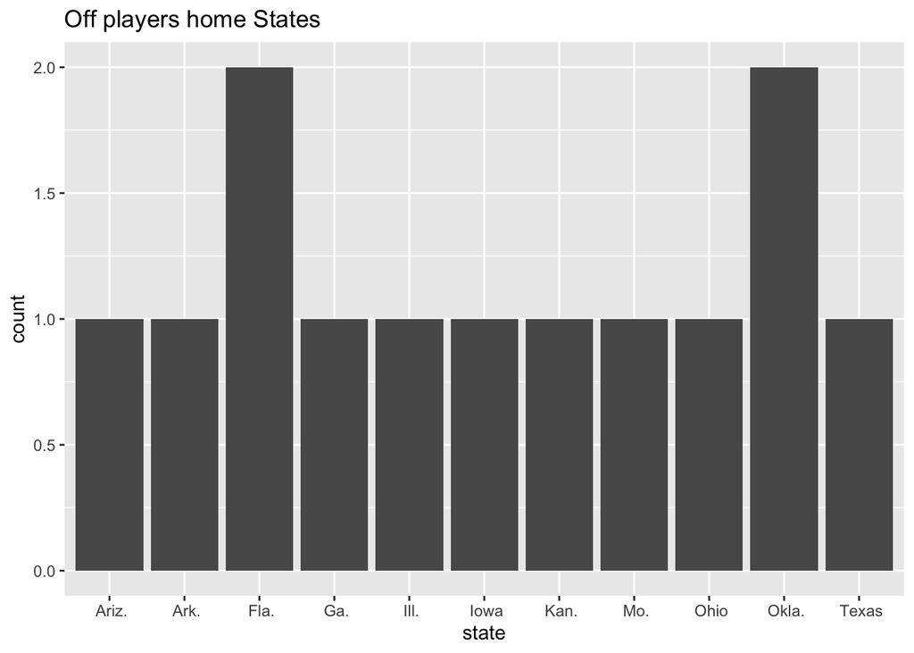

```r
offBio <- offBio %>%
  select(state, Name) %>%
  distinct(Name, .keep_all = TRUE)

ggplot(offBio, aes(x = state)) +  geom_bar() + labs(title = "Off players home States")
```

```r
offBio %>%
  group_by(state) %>%
  summarize(count = n())
```

```
## # A tibble: 11 x 2
##    state    count
##    <chr>    <int>
##  1 " Ariz."     1
##  2 " Ark."      1
##  3 " Fla."      2
##  4 " Ga."       1
##  5 " Ill."      1
##  6 " Iowa"      1
##  7 " Kan."      1
##  8 " Mo."       1
##  9 " Ohio"      1
## 10 " Okla."     2
## 11 " Texas"     1
```

2. How does the performance of quarterback Brock Purdy relate to the performance of the ISU team?

   We can see that Brock Purdy’s performance has the largest effect on the team.

```r
offClean$YdsResponsibleFor <- rowSums(offClean[,c("Rushing_YDS", "Receiving_YDS", "Passing_YDS")], na.rm=TRUE)
offClean %>%
  group_by(Name) %>%
  summarize(AvgYdsResponsibleFor = mean(YdsResponsibleFor)) %>%
  arrange(desc(AvgYdsResponsibleFor))
```

```
## # A tibble: 17 x 2
##    Name                AvgYdsResponsibleFor
##    <fct>                              <dbl>
##  1 Purdy, Brock                      325.
##  2 Hall, Breece                       95.8
##  3 Jones, Deshaunte                   71.6
##  4 Milton, Tarique                    55.5
##  5 Kolar, Charlie                     53.6
##  6 Pettway, La'Michael                52
##  7 Lang, Johnnie                      24.3
##  8 Mitchell, Re-al                    23.4
##  9 Shaw Jr., Sean                     21
## 10 Croney Jr., Sheldon                13
## 11 Allen, Chase                       12.8
## 12 Brock, Jirehl                      12
## 13 Nwangwu, Kene                       9.46
## 14 Akers, Landen                       9
## 15 Soehner, Dylan                      8.92
## 16 Wilson, Darren                      4.54
## 17 Scates, Joe                         2.5
```

3. Which ISU player(s) made big progress over the last year? Compare the 2019 and the 2018 data here.

   Answer

```r
defense18 <- read_excel('cyclonesFootball2018.xlsx', sheet='Defensive')
defClean18 <- defense18 %>%
              mutate(across(c("Name", "Opponent_Opponent"), as.factor)) %>%
              mutate_if(is.character, as.numeric, na.rm = TRUE)
defClean19 <- defCleanOrig

defClean18 <- defClean18 %>%
  group_by(Name) %>%
  select(-Opponent_Opponent) %>%
  summarize_all(list(mean), na.rm=TRUE)

defClean19 <- defClean19 %>%
  group_by(Name) %>%
  select(-Opponent_Opponent) %>%
  summarize_all(list(mean), na.rm=TRUE)

colnames(defClean18) <- paste("Last", colnames(defClean18), sep = "_")
colnames(defClean19) <- paste("This", colnames(defClean19), sep = "_")
DefCompare <- inner_join(defClean18, defClean19, by = c("Last_Name" = "This_Name"))
DefCompare$DiffTacklesSolo <- DefCompare$This_Tackles_Solo - DefCompare$Last_Tackles_Solo
DefCompare$DiffTacklesSack <- DefCompare$This_Tackles_Sack - DefCompare$Last_Tackles_Sack
DefCompare$DiffTacklesAsst <- DefCompare$This_Tackles_ASST - DefCompare$Last_Tackles_ASST

DefCompare %>%
  select(Last_Name, DiffTacklesSolo, DiffTacklesSack, DiffTacklesAsst) %>%
  arrange(desc(DiffTacklesSack)) %>%
  head(1)
```

```
## # A tibble: 1 x 4
##   Last_Name     DiffTacklesSolo DiffTacklesSack DiffTacklesAsst
##   <fct>                   <dbl>           <dbl>           <dbl>
## 1 Vance, O'Rien            1.56           0.405            1.76
```

```r
DefCompare %>%
  select(Last_Name, DiffTacklesSolo, DiffTacklesSack, DiffTacklesAsst) %>%
  arrange(desc(DiffTacklesAsst)) %>%
  head(1)
```

```
## # A tibble: 1 x 4
##   Last_Name     DiffTacklesSolo DiffTacklesSack DiffTacklesAsst
##   <fct>                   <dbl>           <dbl>           <dbl>
## 1 Vance, O'Rien            1.56           0.405            1.76
```

```r
DefCompare %>%
  select(Last_Name, DiffTacklesSolo, DiffTacklesSack, DiffTacklesAsst) %>%
  arrange(desc(DiffTacklesSolo)) %>%
  head(1)
```

```
## # A tibble: 1 x 4
##   Last_Name         DiffTacklesSolo DiffTacklesSack DiffTacklesAsst
##   <fct>                       <dbl>           <dbl>           <dbl>
## 1 Johnson , Anthony            1.78           0.154             0.5
```

```
 These comparisons show the statistics for who improved the most on the season. O'Rien Vance most improved in sacks and assisted tackles and Anthony Johnson most improved in solo tackles.
```

```r
off18 <- read_excel('cyclonesFootball2018.xlsx', sheet='Offensive')
offClean18 <- off18 %>%
              mutate(across(c("Name", "Opponent_Opponent"), as.factor)) %>%
              mutate_if(is.character, as.numeric, na.rm = TRUE)
offClean19 <- offClean

offClean18 <- offClean18 %>%
  group_by(Name) %>%
  select(-Opponent_Opponent) %>%
  summarize_all(list(mean), na.rm=TRUE)

offClean19 <- offClean19 %>%
  group_by(Name) %>%
  select(-Opponent_Opponent) %>%
  summarize_all(list(mean), na.rm=TRUE)

colnames(offClean18) <- paste("Last", colnames(offClean18), sep = "_")
colnames(offClean19) <- paste("This", colnames(offClean19), sep = "_")
OffCompare <- inner_join(offClean18, offClean19, by = c("Last_Name" = "This_Name"))
OffCompare$DiffRecYds <- OffCompare$This_Receiving_YDS - OffCompare$Last_Receiving_YDS
OffCompare$DiffPassingYds <- OffCompare$This_Passing_YDS - OffCompare$Last_Passing_YDS
OffCompare$DiffRushingYds <- OffCompare$This_Rushing_YDS - OffCompare$Last_Rushing_YDS


OffCompare %>%
  select(Last_Name, DiffRecYds, DiffPassingYds, DiffRushingYds) %>%
  arrange(desc(DiffRushingYds)) %>%
  head(1)
```

```
## # A tibble: 1 x 4
##   Last_Name     DiffRecYds DiffPassingYds DiffRushingYds
##   <fct>              <dbl>          <dbl>          <dbl>
## 1 Lang, Johnnie          2            NaN           13.2
```

```r
OffCompare %>%
  select(Last_Name, DiffRecYds, DiffPassingYds, DiffRushingYds) %>%
  arrange(desc(DiffRecYds)) %>%
  head(1)
```

```
## # A tibble: 1 x 4
##   Last_Name      DiffRecYds DiffPassingYds DiffRushingYds
##   <fct>               <dbl>          <dbl>          <dbl>
## 1 Kolar, Charlie       43.1            NaN            NaN
```

```r
OffCompare %>%
  select(Last_Name, DiffRecYds, DiffPassingYds, DiffRushingYds) %>%
  arrange(desc(DiffPassingYds)) %>%
  head(1)
```

```
## # A tibble: 1 x 4
##   Last_Name    DiffRecYds DiffPassingYds DiffRushingYds
##   <fct>             <dbl>          <dbl>          <dbl>
## 1 Purdy, Brock        NaN           81.3          -11.6
```

```
There are existing null values but they dont interfere with finding who most improved. Charlie Kolar improved the most on charging yards. Johnnie Lang improved the most on rushing yards. Brock Purdy on passing yards.
```